# BackGround

A credit card is one of the most used financial products to make online purchases and payments. Though the Credit cards can be a convenient way to manage your finances, they can also be risky. Credit card fraud is the unauthorized use of someone else's credit card or credit card information to make purchases or withdraw cash. It is important that credit card companies are able to recognize fraudulent credit card transactions so that customers are not charged for items that they did not purchase.

The dataset contains transactions made by credit cards in September 2013 by European cardholders. This dataset presents transactions that occurred in two days, where we have 492 frauds out of 284,807 transactions. The dataset is highly unbalanced, the positive class (frauds) account for 0.172% of all transactions.

We have to build a classification model to predict whether a transaction is fraudulent or not.

```python
#importing required libraries
import pandas as pd
import numpy as np
import matplotlib.pyplot as plt
import seaborn as sns
import math
import sklearn
from sklearn.preprocessing import StandardScaler
from sklearn.model_selection import train_test_split,GridSearchCV
from sklearn.linear_model import LogisticRegression
from sklearn.tree import DecisionTreeClassifier
from sklearn.metrics import confusion_matrix, roc_curve, precision_recall_curve,accuracy_score,precision_score
from sklearn.metrics import classification_report,recall_score,f1_score
```

```python
import warnings
warnings.filterwarnings('ignore')
%matplotlib inline
```

```python
#Reading dataset
df = pd.read_csv(r'C:\Users\Vipin\Desktop\creditcard.csv')
```

```python
df
```

|  | Time | V1 | V2 | V3 | V4 | V5 | V6 | V7 | V8 | V9 | ... | V21 | V22 | V23 | V24 | V25 | V26 | V27 | V28 | Amount | Class |
| --- | --- | --- | --- | --- | --- | --- | --- | --- | --- | --- | --- | --- | --- | --- | --- | --- | --- | --- | --- | --- | --- |
| 0 | 0.0 | -1.359807 | -0.072781 | 2.536347 | 1.378155 | -0.338321 | 0.462388 | 0.239599 | 0.098698 | 0.363787 | ... | -0.018307 | 0.277838 | -0.110474 | 0.066928 | 0.128539 | -0.189115 | 0.133558 | -0.021053 | 149.62 | 0 |
| 1 | 0.0 | 1.191857 | 0.266151 | 0.166480 | 0.448154 | 0.060018 | -0.082361 | -0.078803 | 0.085102 | -0.255425 | ... | -0.225775 | -0.638672 | 0.101288 | -0.339846 | 0.167170 | 0.125895 | -0.008983 | 0.014724 | 2.69 | 0 |
| 2 | 1.0 | -1.358354 | -1.340163 | 1.773209 | 0.379780 | -0.503198 | 1.800499 | 0.791461 | 0.247676 | -1.514654 | ... | 0.247998 | 0.771679 | 0.909412 | -0.689281 | -0.327642 | -0.139097 | -0.055353 | -0.059752 | 378.66 | 0 |
| 3 | 1.0 | -0.966272 | -0.185226 | 1.792993 | -0.863291 | -0.010309 | 1.247203 | 0.237609 | 0.377436 | -1.387024 | ... | -0.108300 | 0.005274 | -0.190321 | -1.175575 | 0.647376 | -0.221929 | 0.062723 | 0.061458 | 123.50 | 0 |
| 4 | 2.0 | -1.158233 | 0.877737 | 1.548718 | 0.403034 | -0.407193 | 0.095921 | 0.592941 | -0.270533 | 0.817739 | ... | -0.009431 | 0.798278 | -0.137458 | 0.141267 | -0.206010 | 0.502292 | 0.219422 | 0.215153 | 69.99 | 0 |
| ... | ... | ... | ... | ... | ... | ... | ... | ... | ... | ... | ... | ... | ... | ... | ... | ... | ... | ... | ... | ... | ... |
| 284802 | 172786.0 | -11.881118 | 10.071785 | -9.834783 | -2.066656 | -5.364473 | -2.606837 | -4.918215 | 7.305334 | 1.914428 | ... | 0.213454 | 0.111864 | 1.014480 | -0.509348 | 1.436807 | 0.250034 | 0.943651 | 0.823731 | 0.77 | 0 |
| 284803 | 172787.0 | -0.732789 | -0.055080 | 2.035030 | -0.738589 | 0.868229 | 1.058415 | 0.024330 | 0.294869 | 0.584800 | ... | 0.214205 | 0.924384 | 0.012463 | -1.016226 | -0.606624 | -0.395255 | 0.068472 | -0.053527 | 24.79 | 0 |
| 284804 | 172788.0 | 1.919565 | -0.301254 | -3.249640 | -0.557828 | 2.630515 | 3.031260 | -0.296827 | 0.708417 | 0.432454 | ... | 0.232045 | 0.578229 | -0.037501 | 0.640134 | 0.265745 | -0.087371 | 0.004455 | -0.026561 | 67.88 | 0 |
| 284805 | 172788.0 | -0.240440 | 0.530483 | 0.702510 | 0.689799 | -0.377961 | 0.623708 | -0.686180 | 0.679145 | 0.392087 | ... | 0.265245 | 0.800049 | -0.163298 | 0.123205 | -0.569159 | 0.546668 | 0.108821 | 0.104533 | 10.00 | 0 |
| 284806 | 172792.0 | -0.533413 | -0.189733 | 0.703337 | -0.506271 | -0.012546 | -0.649617 | 1.577006 | -0.414650 | 0.486180 | ... | 0.261057 | 0.643078 | 0.376777 | 0.008797 | -0.473649 | -0.818267 | -0.002415 | 0.013649 | 217.00 | 0 |

284807 rows × 31 columns

# Exploratory data Analysis

Exploratory data analysis (EDA) is used by data scientists to analyze and investigate data sets and summarize their main characteristics, often employing data visualization methods. It helps determine how best to manipulate data sources to get the answers you need, making it easier for data scientists to discover patterns, spot anomalies, test a hypothesis, or check assumptions.

```python
#Total number of rows and columns
df.shape
```

```
(284807, 31)
```

```python
df.describe()
```

|  | Time | V1 | V2 | V3 | V4 | V5 | V6 | V7 | V8 | V9 | ... | V21 | V22 | V23 | V24 | V25 | V26 | V27 | V28 | Amount | Class |
| --- | --- | --- | --- | --- | --- | --- | --- | --- | --- | --- | --- | --- | --- | --- | --- | --- | --- | --- | --- | --- | --- |
| count | 284807.000000 | 2.848070e+05 | 2.848070e+05 | 2.848070e+05 | 2.848070e+05 | 2.848070e+05 | 2.848070e+05 | 2.848070e+05 | 2.848070e+05 | 2.848070e+05 | ... | 2.848070e+05 | 2.848070e+05 | 2.848070e+05 | 2.848070e+05 | 2.848070e+05 | 2.848070e+05 | 2.848070e+05 | 2.848070e+05 | 284807.000000 | 284807.000000 |
| mean | 94813.859575 | 1.759061e-12 | -8.251130e-13 | -9.654937e-13 | 8.321385e-13 | 1.649999e-13 | 4.248366e-13 | -3.054600e-13 | 8.777971e-14 | -1.179749e-12 | ... | -3.405756e-13 | -5.723197e-13 | -9.725856e-13 | 1.464150e-12 | -6.987102e-13 | -5.617874e-13 | 3.332082e-12 | -3.518874e-12 | 88.349619 | 0.001727 |
| std | 47488.145955 | 1.958696e+00 | 1.651309e+00 | 1.516255e+00 | 1.415869e+00 | 1.380247e+00 | 1.332271e+00 | 1.237094e+00 | 1.194353e+00 | 1.098632e+00 | ... | 7.345240e-01 | 7.257016e-01 | 6.244603e-01 | 6.056471e-01 | 5.212781e-01 | 4.822270e-01 | 4.036325e-01 | 3.300833e-01 | 250.120109 | 0.041527 |
| min | 0.000000 | -5.640751e+01 | -7.271573e+01 | -4.832559e+01 | -5.683171e+00 | -1.137433e+02 | -2.616051e+01 | -4.355724e+01 | -7.321672e+01 | -1.343407e+01 | ... | -3.483038e+01 | -1.093314e+01 | -4.480774e+01 | -2.836627e+00 | -1.029540e+01 | -2.604551e+00 | -2.256568e+01 | -1.543008e+01 | 0.000000 | 0.000000 |
| 25% | 54201.500000 | -9.203734e-01 | -5.985499e-01 | -8.903648e-01 | -8.486401e-01 | -6.915971e-01 | -7.682956e-01 | -5.540759e-01 | -2.086297e-01 | -6.430976e-01 | ... | -2.283949e-01 | -5.423504e-01 | -1.618463e-01 | -3.545861e-01 | -3.171451e-01 | -3.269839e-01 | -7.083953e-02 | -5.295979e-02 | 5.600000 | 0.000000 |
| 50% | 84692.000000 | 1.810880e-02 | 6.548556e-02 | 1.798463e-01 | -1.984653e-02 | -5.433583e-02 | -2.741871e-01 | 4.010308e-02 | 2.235804e-02 | -5.142873e-02 | ... | -2.945017e-02 | 6.781943e-03 | -1.119293e-02 | 4.097606e-02 | 1.659350e-02 | -5.213911e-02 | 1.342146e-03 | 1.124383e-02 | 22.000000 | 0.000000 |
| 75% | 139320.500000 | 1.315642e+00 | 8.037239e-01 | 1.027196e+00 | 7.433413e-01 | 6.119264e-01 | 3.985649e-01 | 5.704361e-01 | 3.273459e-01 | 5.971390e-01 | ... | 1.863772e-01 | 5.285536e-01 | 1.476421e-01 | 4.395266e-01 | 3.507156e-01 | 2.409522e-01 | 9.104512e-02 | 7.827995e-02 | 77.165000 | 0.000000 |
| max | 172792.000000 | 2.454930e+00 | 2.205773e+01 | 9.382558e+00 | 1.687534e+01 | 3.480167e+01 | 7.330163e+01 | 1.205895e+02 | 2.000721e+01 | 1.559499e+01 | ... | 2.720284e+01 | 1.050309e+01 | 2.252841e+01 | 4.584549e+00 | 7.519589e+00 | 3.517346e+00 | 3.161220e+01 | 3.384781e+01 | 25691.160000 | 1.000000 |

8 rows × 31 columns

```python
df.columns
```

```
Index(['Time', 'V1', 'V2', 'V3', 'V4', 'V5', 'V6', 'V7', 'V8', 'V9', 'V10',
       'V11', 'V12', 'V13', 'V14', 'V15', 'V16', 'V17', 'V18', 'V19', 'V20',
       'V21', 'V22', 'V23', 'V24', 'V25', 'V26', 'V27', 'V28', 'Amount',
       'Class'],
      dtype='object')
```

```python
df.count()
```

```
Time      284807
V1        284807
V2        284807
V3        284807
V4        284807
V5        284807
V6        284807
V7        284807
V8        284807
V9        284807
V10       284807
V11       284807
V12       284807
V13       284807
V14       284807
V15       284807
V16       284807
V17       284807
V18       284807
V19       284807
V20       284807
V21       284807
V22       284807
V23       284807
V24       284807
V25       284807
V26       284807
V27       284807
V28       284807
Amount    284807
Class     284807
dtype: int64
```

```python
# Check for missing values
missing_values = df.isnull().sum()
missing_values
```

```
Time      0
V1        0
V2        0
V3        0
V4        0
V5        0
V6        0
V7        0
V8        0
V9        0
V10       0
V11       0
V12       0
V13       0
V14       0
V15       0
V16       0
V17       0
V18       0
V19       0
V20       0
V21       0
V22       0
V23       0
V24       0
V25       0
V26       0
V27       0
V28       0
Amount    0
Class     0
dtype: int64
```

There is no missing data in the entire dataset

```python
# Determine number of fraud cases in dataset
fraud = df[df['Class'] == 1]
valid = df[df['Class'] == 0]
outlierFraction = len(fraud)/float(len(valid))
print(outlierFraction)
print('Fraud Cases: {}'.format(len(df[df['Class'] == 1])))
print('Valid Transactions: {}'.format(len(df[df['Class'] == 0])))
```

```
0.0017304750013189597
Fraud Cases: 492
Valid Transactions: 284315
```

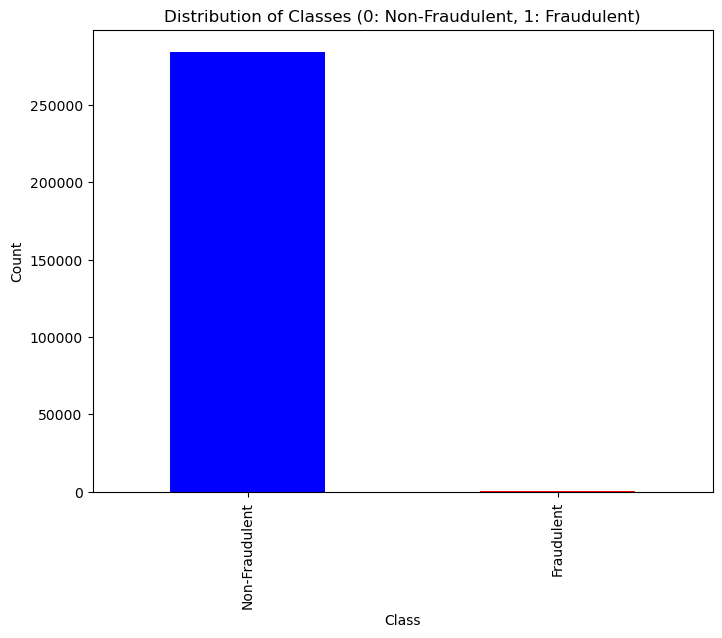

```python
# Visualize the distribution of 'Class' (fraudulent vs. non-fraudulent transactions)
plt.figure(figsize=(8, 6))
df['Class'].value_counts().plot(kind='bar', color=['blue', 'red'])
plt.title('Distribution of Classes (0: Non-Fraudulent, 1: Fraudulent)')
plt.xlabel('Class')
plt.ylabel('Count')
plt.xticks([0,1], ['Non-Fraudulent','Fraudulent'])
plt.show()
```

Only 492 (or 0.172%) of transaction are fraudulent. That means the data is highly unbalanced with respect with target variable Class.

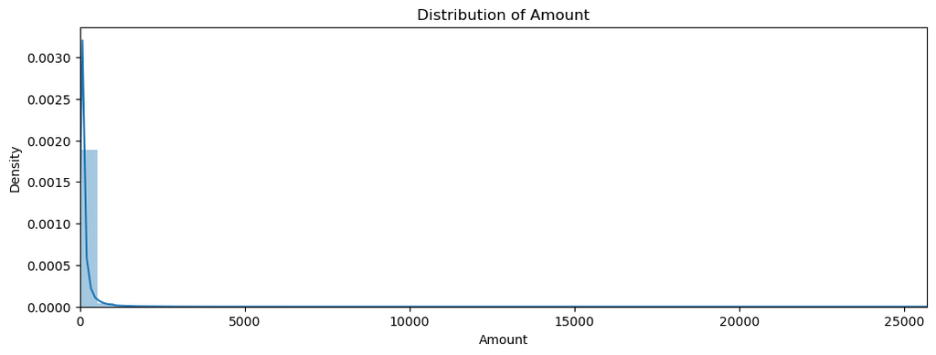

```python
amount_val = df['Amount'].values
plt.figure(figsize = (12,4))
sns.distplot(df['Amount'])
plt.xlim(min(amount_val),max(amount_val))
plt.title("Distribution of Amount")
```

The amount variable is mostly dense around the smallar amount regions.

### Check for duplicates

```python
#Deleting duplicate columns
df = df.drop_duplicates()
df.count()
```

```
Time      283726
V1        283726
V2        283726
V3        283726
V4        283726
V5        283726
V6        283726
V7        283726
V8        283726
V9        283726
V10       283726
V11       283726
V12       283726
V13       283726
V14       283726
V15       283726
V16       283726
V17       283726
V18       283726
V19       283726
V20       283726
V21       283726
V22       283726
V23       283726
V24       283726
V25       283726
V26       283726
V27       283726
V28       283726
Amount    283726
Class     283726
dtype: int64
```

### Getting the correct datatype for the date

While working with data in Pandas, it is not an unusual thing to encounter time series data. We cannot perform any time series-based operation on the dates if they are not in the right format. To be able to work with it, we are required to convert the dates into the correct format.

```python
timedelta = pd.to_timedelta(df['Time'],unit='s')

df['Time_min'] = (timedelta.dt.components.minutes).astype(int)
df['Time_hour'] = (timedelta.dt.components.hours).astype(int)
```

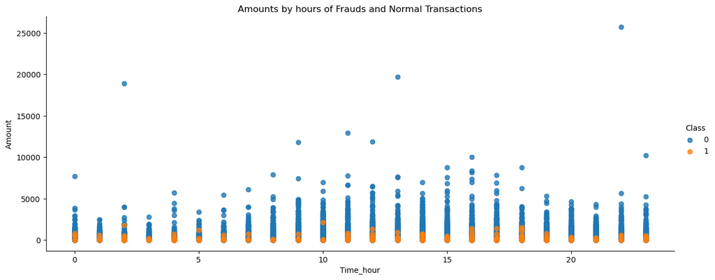

```python
#amount vs time distribution
ax = sns.lmplot(y='Amount',x='Time_hour',fit_reg=False,aspect=2.5,data=df,hue='Class')
plt.title("Amounts by hours of Frauds and Normal Transactions",fontsize=12)
```

The pattern oberserved above about non-fraud and fraud transactions are much more uniform accorss the day.

#### Visualization using boxplot

One important part beyond simply pulling summary statistical methods is to get a visual sense of the distributions of various variables within a given Series or Series by category using boxplots.

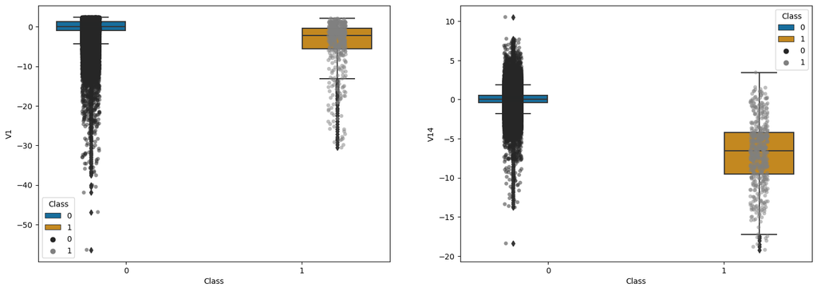

```python
cols = ['V1', 'V14']
f, axes = plt.subplots(1, 2, figsize=(18, 6), sharex=True)
for index,col in enumerate(cols):
    sns.boxplot(x="Class", y=col, hue="Class", palette="colorblind", data=df, ax=axes[index])
    sns.stripplot(x='Class', y=col,  data=df,dodge=True,jitter=True,marker='o',ax=axes[index],alpha=0.5,color='grey',hue='Class')
plt.show()
plt.clf()
plt.close()
```

#### Visualisation using distribution plot

Distribution plots are used to visualize univariate distributions of observations

They can be used to identify outliers, identify how normal a dataset is, and whether there are potential gaps in your dataset, along with other applications.

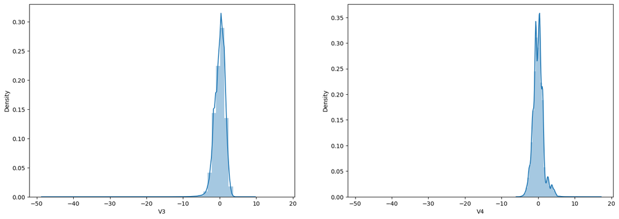

```python
f, axes = plt.subplots(1, 2, figsize=(18, 6), sharex=True)
sns.distplot(df['V3'],ax=axes[0])
sns.distplot(df['V4'],ax=axes[1])

plt.show()
plt.clf()
plt.close()
```

#### Visualisation using Joint plot

While histograms are useful to view, they are still ostensively univatiate in nature, meaning they only show the distribution of one variable at a time.

When we want to compare two variables distributions at a time in Python, we can use the joint plot function.

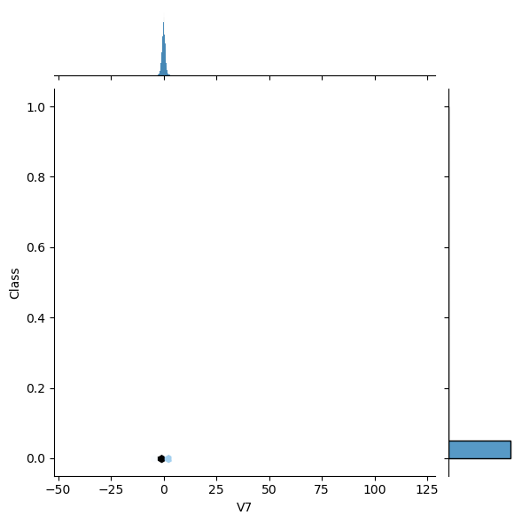

```python
sns.jointplot(y='Class',x='V7',data=df,kind='hex')
```

#### Visualisation using scatter plot

Another common method of performing bivariate analysis, or comparing more than one variable, is to use scatter plots and pair plots.Scatter plots are useful to show individual values plot on a two dimensional cartesian X & Y plane from two Series in a Pandas DataFrame.

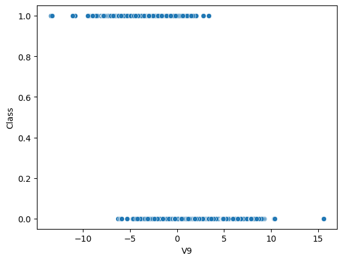

```python
sns.scatterplot(x="V9", y="Class",data=df)
```

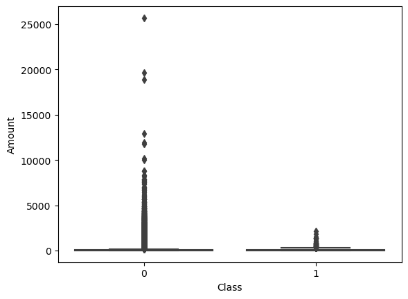

```python
sns.boxplot(y="Amount", x="Class",data=df)
```

#### Visualisation using pair plot

Pair plots can play a similar role to individual scatter plots as they provide a variety of visualizations

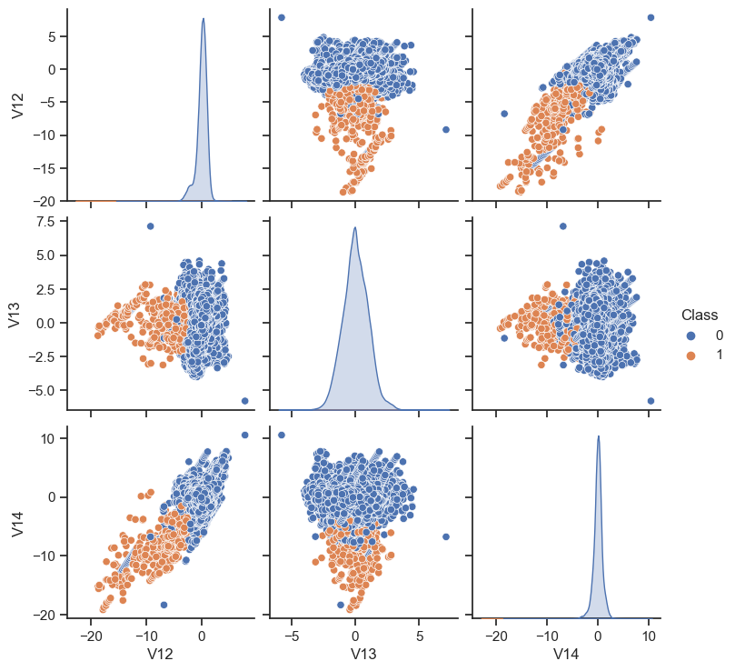

```python
sns.set(style="ticks")
sns.pairplot(df[["V12","V13","V14","Class"]], hue="Class")
```

#### Correlation matrix

A correlation matrix is a common tool used to compare the coefficients of correlation between different features (or attributes) in a dataset. It allows us to visualize how much (or how little) correlation exists between different variables. This is an important step in pre-processing machine learning pipelines. Since the correlation matrix allows us to identify variables that have high degrees of correlation, they allow us to reduce the number of features we may have in a dataset. This is often referred to as dimensionality reduction and can be used to improve the runtime and effectiveness of our models.

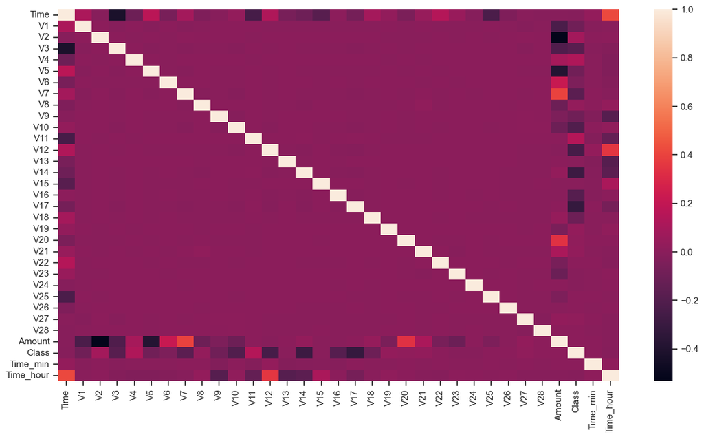

```python
f, ax = plt.subplots(figsize=(15, 8))
corr = df.corr()
sns.heatmap(corr,
            xticklabels=corr.columns.values,
            yticklabels=corr.columns.values)
```

In the HeatMap we can clearly see that most of the features do not correlate to other features but there are some features that either has a positive or a negative correlation with each other. For example, V2 and V5 are highly negatively correlated with the feature called Amount. We also see some correlation with V20 and Amount. This gives us a deeper understanding of the Data available to us.

# Data Cleaning

#### Standardisation of dataset

It is better idea to scale the features before using the dataset so that all the values come in similar range. This is important so that features with lesser significance might not end up dominating the more significant features due to its larger range.

Different types of Scaling-Log, Standardization and Normalization is used. We’ll decide which of these to choose from depending on our dataset.

Log is a scaling technique which is done when the variables span several orders of magnitude.

Standardization is a scaling technique are the ones where the values are centered around the mean with a unit standard deviation. This means that the mean of the attribute becomes zero and the resultant distribution has a unit standard deviation.

Normalization (Min-Max Scaling) is a scaling technique in which values are shifted and are then rescaled so that they end up ranging between 0 and 1.

```python
#Scale amount by Standardization
ss = StandardScaler()
df['amount_scaled'] = ss.fit_transform(df['Amount'].values.reshape(-1,1))
```

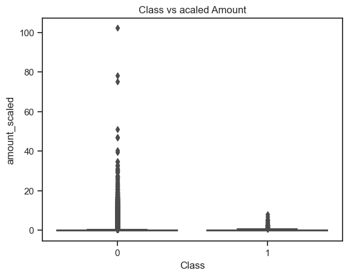

```python
sns.boxplot(x ="Class",y="amount_scaled",data=df)
plt.title("Class vs acaled Amount")
plt.show()
```

### Train and Test Split

We will be dividing the dataset into two main groups. One for training the model and the other for Testing our trained model’s performance.

```python
# Prepare features and target
# Using Scikit-learn to split data into training and testing sets

X = df.drop(['Time','Class'], axis=1)
y = df['Class']

# Split the data into training and testing sets
X_train, X_test, y_train, y_test = train_test_split( X,y, test_size = 0.2,stratify=df['Class'])
print(X_train.shape,X_test.shape)
```

```
(226980, 32) (56746, 32)
```

```python
#Inspect whether the 2 sets are indeed stratified.
print(pd.Series(y_train).value_counts(normalize = True))
print(pd.Series(y_test).value_counts(normalize = True))
```

```
Class
0    0.998335
1    0.001665
Name: proportion, dtype: float64
Class
0    0.998326
1    0.001674
Name: proportion, dtype: float64
```

#### Handling imbalanced data

As the dataset is an imbalanced dataset, we can’t just simply use it raw and proced it into machine learning. It could cause a biased to the majority of the class that leads to a poor machine learning model.

So, we have to handle the imbalanced dataset first.

```python
#Apply SMOTE to create synthetic observations from minority class

print("X_train: ",X_train.shape)
print("y_train: ",y_train.shape)
print("X_test: ",X_test.shape)
print("y_test: ",y_test.shape)

print('\n')
print('............')
print('\n')

from imblearn.over_sampling import SMOTE #Over sampling
smote= SMOTE()
X_train_smote,y_train_smote=smote.fit_resample(X, y)
X_test_smote, y_test_smote = X_test, y_test

print("X_train_smote: ",X_train_smote.shape)
print("y_train_smote: ",y_train_smote.shape)
print("X_test_smote: ",X_test_smote.shape)
print("y_test_smote: ",y_test_smote.shape)
```

```
X_train:  (226980, 32)
y_train:  (226980,)
X_test:  (56746, 32)
y_test:  (56746,)


............


X_train_smote:  (566506, 32)
y_train_smote:  (566506,)
X_test_smote:  (56746, 32)
y_test_smote:  (56746,)
```

# Feature Engineering

```python
from sklearn.ensemble import RandomForestClassifier
rf =RandomForestClassifier (class_weight='balanced', random_state=123)
rf.fit(X_train,y_train)
```

```
RandomForestClassifier(class_weight='balanced', random_state=123)
```

```python
importances = rf.feature_importances_
sorted(importances)
```

```
[0.004022749034284361,
 0.0044973549117333375,
 0.004700329166026917,
 0.0052054962507417785,
 0.006149040312804969,
 0.006187694226452039,
 0.006226995456891837,
 0.00626295757158413,
 0.006573983448009877,
 0.006606091486013047,
 0.006755916178322601,
 0.007072424960532032,
 0.00742898291652875,
 0.009061433913234003,
 0.010059400571967988,
 0.010355070854247278,
 0.010355778262862103,
 0.011100179870110824,
 0.011430525754156375,
 0.011891038668811896,
 0.014194221202724577,
 0.015171417043451011,
 0.015702404623937762,
 0.03826384412929034,
 0.04141287624368879,
 0.04353634401896717,
 0.05047304473712365,
 0.07133348382525484,
 0.09014528162301717,
 0.15161452845090276,
 0.15484661874785274,
 0.16136249153847315]
```

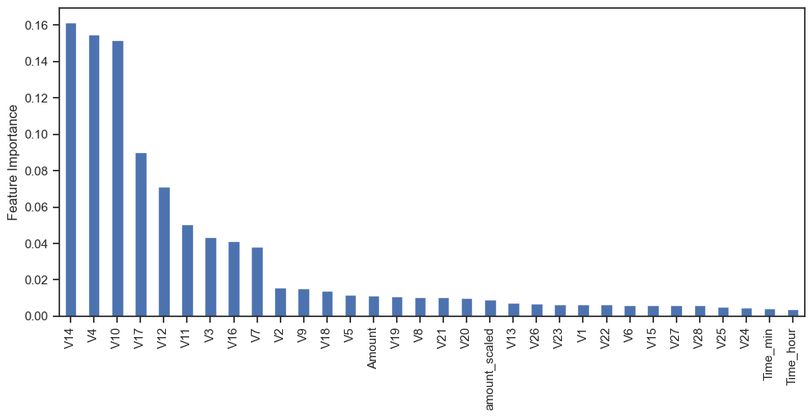

```python
feature_importances = pd.Series(importances, index=X_train.columns)
fig, ax = plt.subplots(figsize=(12, 5))
feature_importances.sort_values(ascending=False).plot.bar(ax=ax)
ax.set_ylabel("Feature Importance")
plt.show()
```

# Model Selection and Model Training

### Decision Tree Classifier

```python
from sklearn.tree import DecisionTreeClassifier
```

```python
dt = DecisionTreeClassifier()
dt.fit(X_train,y_train)
```

```
DecisionTreeClassifier()
```

```python
pred_train_dt = dt.predict(X_train)
pred_dt = dt.predict(X_test)
```

```python
matrix_dt = confusion_matrix(y_test, pred_dt)
matrix_dt
```

```
array([[56614,    37],
       [   20,    75]], dtype=int64)
```

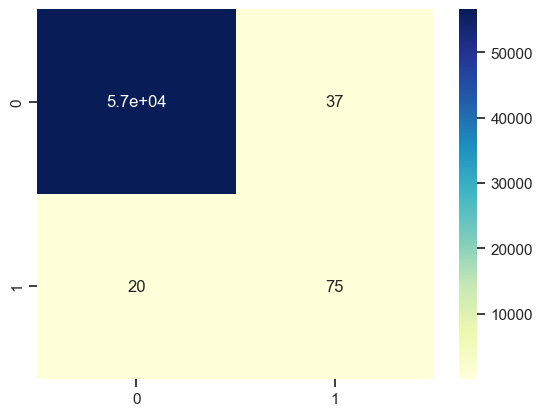

```python
sns.heatmap(data=matrix_dt, annot=True , cmap="YlGnBu")
plt.show()
```

```python
from sklearn.metrics import confusion_matrix, recall_score, precision_score, f1_score, accuracy_score
from sklearn import metrics
from imblearn.pipeline import Pipeline, make_pipeline
```

```python
def model_eval(y_test, predicted):

    accuracy = accuracy_score(y_test, predicted)*100
    precision = precision_score(y_test, predicted)*100
    recall = recall_score(y_test, predicted)*100
    f1 = f1_score(y_test, predicted) *100
    confusion_matrix =metrics.confusion_matrix(y_test, predicted)
    cm_display = metrics.ConfusionMatrixDisplay(confusion_matrix=confusion_matrix, display_labels=[False, True])
    cm_display.plot()
    plt.grid(False)
    plt.show()

    auc = np.NaN
    if auc:
        auc = metrics.roc_auc_score(y_test, predicted )*100
        fpr, tpr, threshold = roc_curve(y_test, predicted)
        plt.plot(fpr, tpr, label='Model', c='blue')
        plt.plot([0, 1], [0, 1], linestyle='--', c='yellow')
        plt.title("ROC Curve")
        plt.legend()
        plt.show()

    print('Accuracy:',accuracy  )
    print('Precision:', precision )
    print('Recall:', recall)
    print('F1 Score:', f1)
    print('AUC:', auc)
    print('Classification Report:',classification_report)

    return [recall, precision, f1, auc]
```

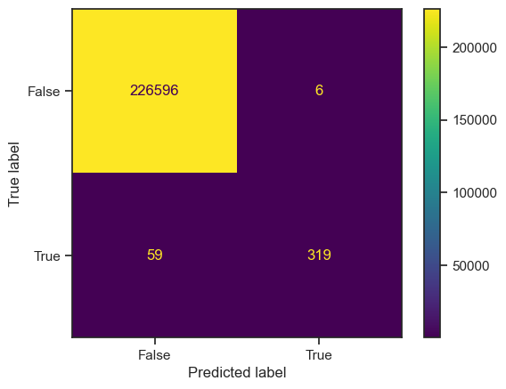

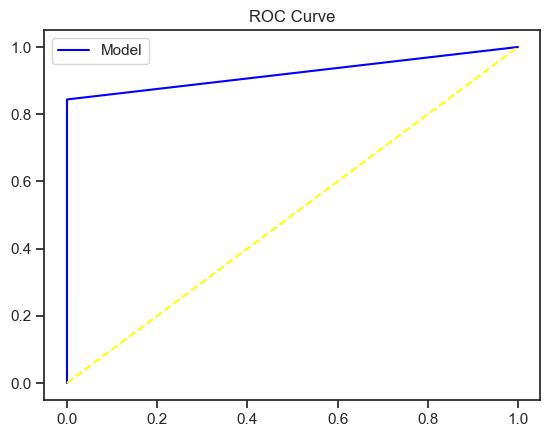

[output not shown]

```
[84.39153439153439, 98.15384615384616, 0.9075391180654339, 92.19444328865252]
```

```python
model_eval(y_train, pred_train_dt)
```

[figure not shown]

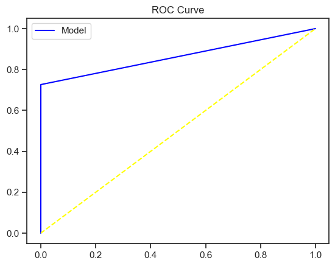

[output not shown]

```
[72.63157894736842, 92.0, 0.811764705882353, 86.31049389196457]
```

```python
model_eval(y_test, pred_dt)
```

```python
from sklearn.model_selection import GridSearchCV
parameters = {
    'max_depth': [1,2,3,4,5,6,7,8,9,10],
   'min_samples_split' : [10,20,30,40,50,60]
}
grid_search_dt = GridSearchCV(estimator = dt,
                             param_grid = parameters,
                             scoring = 'accuracy',
                             cv = 10,
                             n_jobs = -1)
grid_search_dt = grid_search_dt.fit(X_train,y_train)
best_accuracy = grid_search_dt.best_score_
best_parameters = grid_search_dt.best_params_
best_parameters
```

```
{'max_depth': 5, 'min_samples_split': 10}
```

```python
pred_gstrain_dt =grid_search_dt.predict(X_train)
pred_gstest_dt = grid_search_dt.predict(X_test)
```

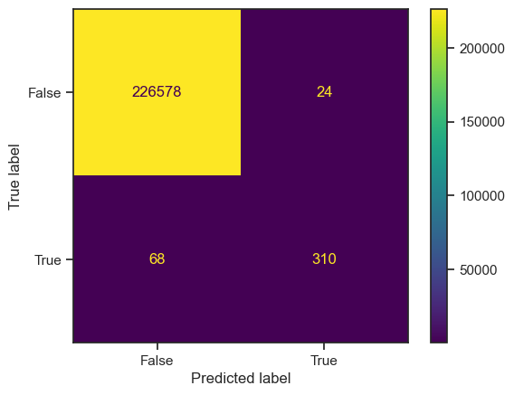

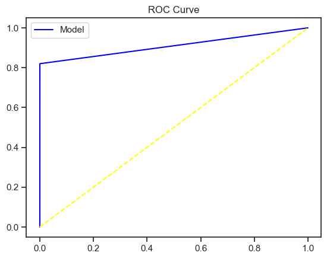

```
Accuracy: 99.95946779451934
Precision: 92.81437125748504
Recall: 82.01058201058201
F1 Score: 87.07865168539325
AUC: 90.9999953768323
Classification Report: <function classification_report at 0x00000148D67B1260>
```

```
[82.01058201058201, 92.81437125748504, 87.07865168539325, 90.9999953768323]
```

```python
model_eval(y_train, pred_gstrain_dt)
```

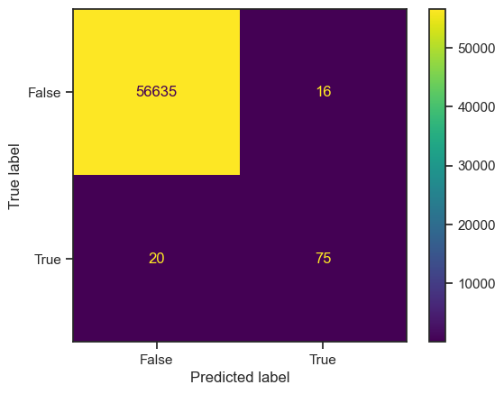

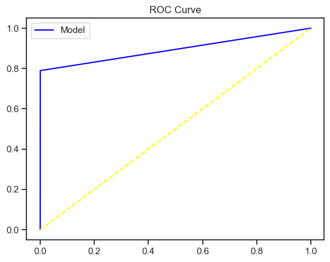

```
Accuracy: 99.93655940506821
Precision: 82.41758241758241
Recall: 78.94736842105263
F1 Score: 80.64516129032259
AUC: 89.4595626592739
Classification Report: <function classification_report at 0x00000148D67B1260>
```

```
[78.94736842105263, 82.41758241758241, 80.64516129032259, 89.4595626592739]
```

```python
model_eval(y_test, pred_gstest_dt)
```

```python
matrix_gs_dt = confusion_matrix(y_test, pred_gstest_dt)
matrix_gs_dt
```

```
array([[56635,    16],
       [   20,    75]], dtype=int64)
```

Obtained 82.46% precision, 78.94% recall and 81% f1 score and 90% AOC score.

## Model Evaluation

we'll evaluate model using:

ROC AUC Score

ROC Curve

Confusion Matrix

Classification report

```python
from sklearn.metrics import roc_auc_score

print('Decision Tree Classifier: ', roc_auc_score(y_test, pred_dt))
print('Decision Tree Classifier_GridSearch_CV: ', roc_auc_score(y_test, pred_gstest_dt))
```

```
Decision Tree Classifier:  0.8944102812325513
Decision Tree Classifier_GridSearch_CV:  0.8945956265927391
```

```python
#Evaluating using ROC Curve
dt_fpr, dt_tpr, dt_threshold = roc_curve(y_test, pred_dt)
dt_gridsearch_fpr, dt_gridsearch_tpr, dt_gridsearch_threshold = roc_curve(y_test, pred_gstest_dt)
```

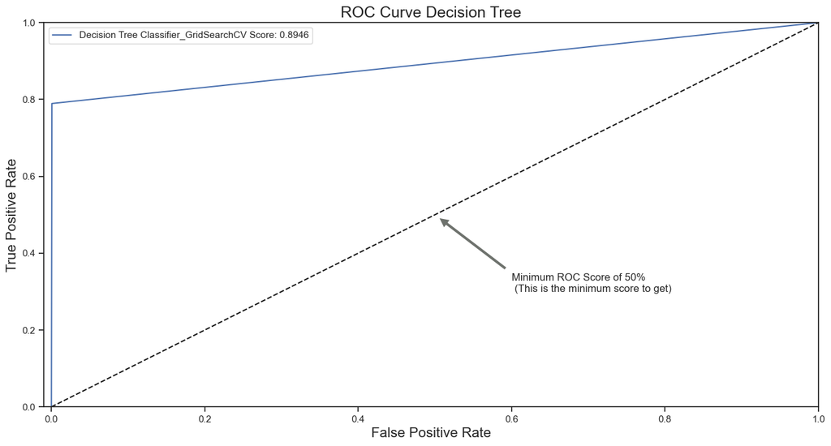

```python
plt.figure(figsize=(16,8))
plt.title('ROC Curve Decision Tree', fontsize=18)

plt.plot(dt_fpr, dt_tpr, label='Decision Tree Classifier_GridSearchCV Score: {:.4f}'.format(roc_auc_score(y_test, pred_gstest_dt)))

plt.plot([0, 1], [0, 1], 'k--')
plt.axis([-0.01, 1, 0, 1])
plt.xlabel('False Positive Rate', fontsize=16)
plt.ylabel('True Positive Rate', fontsize=16)
plt.annotate('Minimum ROC Score of 50% \n (This is the minimum score to get)', xy=(0.5, 0.5), xytext=(0.6, 0.3),
                arrowprops=dict(facecolor='#6E726D', shrink=0.05))
plt.legend()
```

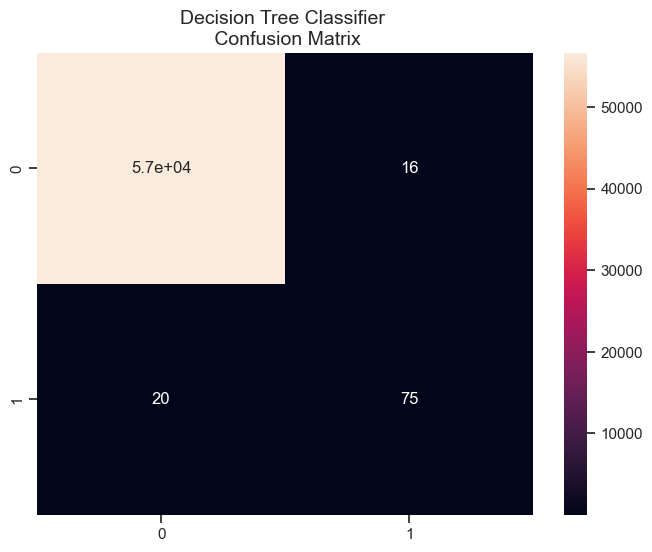

```python
#Confusion Matrix

fig = plt.figure(figsize=(8,6))


sns.heatmap(matrix_gs_dt,  annot=True)
plt.title("Decision Tree Classifier \n Confusion Matrix", fontsize=14)
plt.show()
```

```python
#Evaluation using classification report

def model_class_rep(actual, predicted):
        acc_score = accuracy_score(actual, predicted)
        conf_matrix = confusion_matrix(actual, predicted)
        clas_rep = classification_report(actual, predicted)

        print('Model Accuracy is: ', acc_score)
        print(conf_matrix)
        print(clas_rep)
```

```python
results = model_class_rep(y_test, pred_gstest_dt)
```

```
Model Accuracy is:  0.999365594050682
[[56635    16]
 [   20    75]]
              precision    recall  f1-score   support

           0       1.00      1.00      1.00     56651
           1       0.82      0.79      0.81        95

    accuracy                           1.00     56746
   macro avg       0.91      0.89      0.90     56746
weighted avg       1.00      1.00      1.00     56746
```

```python
#Evaluating using Accuracy
acc_score = accuracy_score(y_test, pred_gstest_dt)
print('Decision Tree Classifier Accuracy : ',round(acc_score * 100,2).astype(str) + '%')
```

```
Decision Tree Classifier Accuracy :  99.94%
```

## Conclusion

Exploratory Data analysis is done for different features.

Prepared Data and build Decision Tree ML Models.

Evaluate model performance w.r.t Accuracy,Precision,Recall and F1 Scores.